# Keelung Facebook Analysis

LU YI

2016-11-01

## Data Source

- 來源：基隆人踹共
- 期間：2014-09-01 - 2016-10-02

### 變數

- Post

```r
names(post_dt)
```

```
 [1] "from_id"        "from_name"      "message"        "created_time"
 [5] "type"           "link"           "id"             "likes_count"
 [9] "comments_count" "shares_count"   "created_date"
```

```r
all_dt <- merge(
  post_dt[, .(id, link, message, created_date)],
  comment_dt[, .(post_id, message, created_time)],
  by.x="id", by.y="post_id", all.x = TRUE)
temp <- all_dt[, .(comment_message = paste(message.y, collapse = "\n>>> ")), by = id]
all_dt <- temp[post_dt, on = c("id")]
# all_dt[, .(message,
#            comment_message,
#            created_date = add_text_url(created_date, link))] %>%
#   DT::datatable(escape = FALSE, options = list(searchHighlight = TRUE))
```

- Comments

```r
names(comment_dt)
```

```
[1] "post_id"      "from_id"      "from_name"    "message"      "created_time"
[6] "likes_count"  "id"
```

- Share

```r
names(share_dt)
```

```
[1] "from_id"     "from_name"   "shared_time" "id"
```

## 貼文聲量分析

### 按讚、分享、回文數量之相關性

針對每則貼文，計算兩兩按讚、分享、回文的相關係數， 按讚數，與回文數及分享數的相關係數分別為 .52, .43，若只以按讚數來看聲量大小，也具有一定的代表性。

```r
d <- post_dt[, .(likes_count, shares_count, comments_count)] %>%
  correlate %>%
  shave()
  # shave(upper = FALSE) %>%
d
```

| rowname | likes_count | shares_count | comments_count |
| --- | --- | --- | --- |
| likes_count | NA | NA | NA |
| shares_count | 0.4287087 | NA | NA |
| comments_count | 0.5156872 | 0.3052601 | NA |

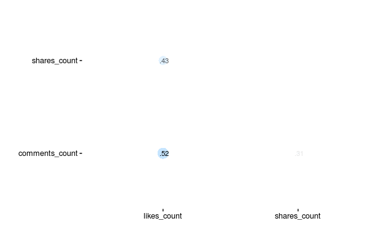

```r
d %>% rplot(print_cor = TRUE)
```

### 按讚

- 按讚聲量分佈

按讚聲量的分佈呈右尾分佈（right skewed），中位數為 67，因此只取前面幾名的貼文作為議題擴散程度較大的代表來分析。

```r
d <- post_dt[order(-likes_count), .(likes_count)]
p <- ggplot(d, aes(likes_count)) +
  geom_histogram(color = "white", binwidth = 50) +
  scale_x_continuous(minor_breaks = seq(0, 3000, 50)) +
  ylab("# of post")
post_dt[, likes_count] %>% summary()
```

```
   Min. 1st Qu.  Median    Mean 3rd Qu.    Max.
    0.0    34.0    67.0   129.1   141.0  2931.0
```

```r
ggplotly(p)
```

[interactive chart not shown]

- 按讚聲量排行榜 Top 10

```r
d <- post_dt[order(-likes_count)][
  1:10, .(message, likes_count,
          created_date = add_text_url(created_date, link))]
DT::datatable(d, escape = FALSE, options = list(searchHighlight = TRUE))
```

|  | message | likes_count | created_date |
| --- | --- | --- | --- |
| 1 | Sandy Tsao說 哇 ，又遇到一個暖男101經祥豐街司機 ，這位司機是陳大鵬先生 ，祥豐市場站有個中風的阿伯柱著拐杖要上車 ，司機先生居然下車去扶阿伯上車耶 ，整車的歐里桑跟歐巴桑一直誇獎司機 ，司機先生還不好意思的說這是他應該做的 ，讚讚讚啦 ！！！ | 2931 | 2015-05-14 |
| 2 | Angelo Lin說 負責任的商家...QQ 辛苦了 | 2413 | 2014-09-05 |
| 3 | 不再照單全收 林右昌：以後基隆自己決定颱風假 | 2315 | 2015-09-29 |
| 4 | 洪敦智說 一大早(還不到六點)大船就進來了^_^。 | 2242 | 2015-09-02 |
| 5 | Yihao Chien說 在循環站等公車時、看到一臺602的公車有位先生抬著一部嬰兒車下來、想說是抱著嬰兒媽媽的老公、沒想到竟然是司機先生!!超級感動的>_<!! | 2110 | 2015-05-19 |
| 6 | 陳思予說 這是基隆市安樂區五福里的里長（歹勢!我忘了他叫什麼？）~我個人早出晚歸，對於上班族而言，“家”就僅是休息的地方。但每逢我遇到“他”，要不打掃街道，要不跟著垃圾車協助里民清倒垃圾，還有就是貼心的廣播應注意的事項。原先，他剛當上里長時，我以為這只是他一時的熱誠，但日子一天天過，他的熱誠不減反增;前天看他滿頭大汗匆匆走過（肯定又接獲里民的請求協助），今天見他在烈陽下拿著除草機（還不忘對路過里民… | 1996 | 2016-08-29 |
| 7 | 基隆連兩週淨海 又見軟絲產卵 | 1865 | 2016-09-12 |
| 8 | 基隆到台北僅200人？基隆市議員駁斥：絕對不止 | 1833 | 2015-03-17 |
| 9 | 滅頂！ 基隆店家大廣告拒買頂新產品 | 1780 | 2015-12-02 |
| 10 | 「基隆人還要活嗎？」國光客運擬改停南港 基隆人反彈 | 1774 | 2015-03-16 |

1. 公車司機
2. 李鵠餅店回收正義香油製品
3. 北北基因為颱風假放半天遭網友罵翻
4. 大船入港照（郵輪）
5. 公車司機
6. 貼心里長
7. 淨灘新聞
8. 台北市國光客運西站部分，調整到南港轉運站爭議
9. 滅頂
10. 客運擬改停南港 基隆人反彈

> 交通問題是重點

### 分享

- 分享聲量分佈

```r
d <- post_dt[order(-shares_count), .(shares_count)]
post_dt[, shares_count] %>% summary()
```

```
   Min. 1st Qu.  Median    Mean 3rd Qu.    Max.
  0.000   0.000   2.000   7.419   6.000 968.000
```

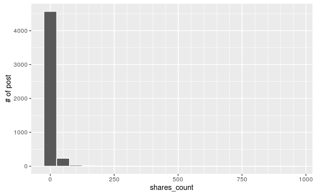

```r
ggplot(d, aes(shares_count)) +
  geom_histogram(color = "white", binwidth = 50) +
  scale_x_continuous(minor_breaks = seq(1, 1000, 50)) +
  ylab("# of post")
```

- 分享聲量排行榜 Top 10

```r
d <- post_dt[order(-shares_count)][
  1:10, .(message, shares_count,
          created_date = sprintf("<a href='%s' target='_blank'>%s</a>",
                                 link, created_date))]
DT::datatable(d, escape = FALSE, options = list(searchHighlight = TRUE))
```

|  | message | shares_count | created_date |
| --- | --- | --- | --- |
| 1 | 不定時炸彈 | 968 | 2016-05-09 |
| 2 | 龍龍說 拜託大家幫我分享一下 好嗎~這個是我同學的阿嬤 她昨天早上出門到現在還沒回家_她從四腳亭出門_基隆的朋友有看到她,請跟我聯絡,謝謝各位幫忙!! 請幫忙努力分享,有看到的人.請跟我聯絡 0970-780564 謝謝各位!!! | 430 | 2016-07-21 |
| 3 | En Ti Chen說 基隆的女性朋友請注意 在501號公車及市區有這位老先生 常常徘徊在這地帶試圖用身體去碰撞年輕女性 | 393 | 2015-11-14 |
| 4 | MoMo Wang說 安一路154號車子下面……被撞……好像腳斷了哀豪……昏過去了……誰能幫幫牠…… 撞牠的你良心何在……還回頭看自己的車有沒有事……就是沒有去看狗… | 338 | 2016-03-21 |
| 5 | 基隆愛四路夜市 今起18天不收攤 | 309 | 2016-01-28 |
| 6 | 蔡依潔說 我是基隆八斗子望海巷的居民 我們這裡有一個海科館成立 現在有財團要在我們這裡蓋飯店 他們連調解會都沒開，現在就要拆我們的房子，甚至是告我們侵佔 這裡的居民都是從小住到現在，都已經6.70歲了 突然接到這種消息，要他們怎麼辦 住了一輩子的家，說拆就拆 這種手段來對付我們 甚至是連市長，里長，都不理我們 請大家幫我們發聲，請幫我們告訴這個世界…… 我們這個小小的漁村就這樣要被壓榨，我們美麗的… | 291 | 2014-10-27 |
| 7 | 基隆、汐止6萬5000戶 15日起停水8小時 | 272 | 2016-05-10 |
| 8 | 蕭璧聰說 我是住新豐街251巷的住戶我姓蕭 ， 你看到的這個影片是十月八號我家裡遭小偷侵入行竊 ，這些影像是我從監視器擷取下的希望有住附近的民眾能幫我 轉發 ，讓住這附近的住戶能夠認清這個人的長相 幫警方破案，因為他的影像清楚以防他再行竊我也已經向八斗派出所警察備案希望不要有下一個受害戶。 | 261 | 2014-10-12 |
| 9 | 費雪說 分辨基隆人已經變成25個了 | 243 | 2015-01-12 |
| 10 | 基隆環保局招考儲備清潔隊員 月薪上看4萬元 | 236 | 2016-07-25 |

### 回文

- 回文聲量排行榜

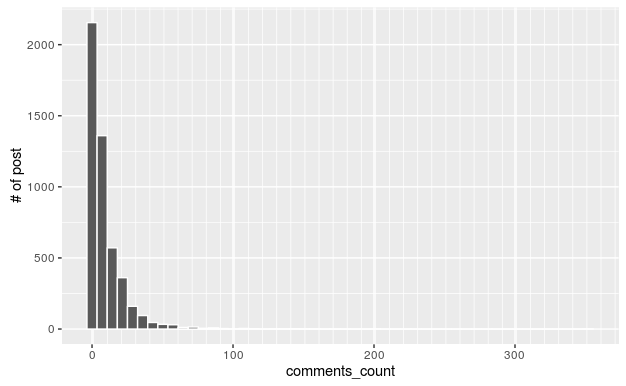

```r
d <- post_dt[order(-comments_count), .(comments_count)]
ggplot(d, aes(comments_count)) +
  geom_histogram(color = "white", bins = 50) +
  scale_x_continuous(minor_breaks = seq(1, 5000, 10)) +
  ylab("# of post")
```

- 回文聲量排行榜 Top 10

回文較多的文章，很多是引起憤怒鄉民的話題

```r
d <- post_dt[order(-comments_count)][
  1:10, .(message, comments_count,
          created_date = sprintf("<a href='%s' target='_blank'>%s</a>",
                                 link, created_date))]
DT::datatable(d, escape = FALSE, options = list(searchHighlight = TRUE))
```

|  | message | comments_count | created_date |
| --- | --- | --- | --- |
| 1 | 梁曉慧說 這是新的車站！不是蚊子館是流浪狗館 | 352 | 2015-08-22 |
| 2 | 基隆到台北僅200人？基隆市議員駁斥：絕對不止 | 201 | 2015-03-17 |
| 3 | 幫我匿名，謝謝！ 在遊行開始沒多久，我在仁祥醫院前的天橋上架腳架和相機，一位員警走過來告訴我，天橋是給人走的，不可在此逗留。 我問：不能拍照嗎？ 員警：我只是勸導。 我：不走你要抓我嗎？ 員警：我只是勸導。 請問基隆市有規定天橋不可拍照嗎？那位員警是鬼打牆嗎？一直重複：我只是勸導。 | 161 | 2016-08-17 |
| 4 | Litchi Chang說 原來我們基隆人欠謝立功一份人情? | 151 | 2014-10-03 |
| 5 | 基隆廟口蝦仁羹名攤遭訴 拒賣單點滷肉飯 | 144 | 2015-07-18 |
| 6 | 不定時炸彈 | 141 | 2016-05-09 |
| 7 | Angelo Lin說 負責任的商家...QQ 辛苦了 | 133 | 2014-09-05 |
| 8 | 邱華生說 基隆市，並不富有，老人坐公車，還不用錢，讓老人免費有坐公車出遊的感覺，公車上，老人比例佔多數，市長，這樣對的起年輕的選票嗎，這樣公平嗎？ | 128 | 2016-02-03 |
| 9 | 「基隆人還要活嗎？」國光客運擬改停南港 基隆人反彈 | 118 | 2015-03-16 |
| 10 | 基隆新火車站啟用 議員要求免費試乘一個月 | 115 | 2015-05-08 |

## 文字探勘

### 貼文

- 關鍵詞 Top 100

利用 tf-idf 關鍵詞算法，處理高頻詞高估及低頻詞低估的問題，取得整個文檔的關鍵詞

```r
key_term <- dtm_train_tfidf %>% find_freq_terms(3) %>%
  colSums %>%
  data.frame() %>%
  data.table(keep.rownames = TRUE) %>%
  setnames(c("keyword", "sum_tf_idf")) %>%
  .[order(-sum_tf_idf)]
key_term %>% head(100) %>% DT::datatable()
```

|  | keyword | sum_tf_idf |
| --- | --- | --- |
| 1 | 基隆 | 94.7209332885824 |
| 2 | 找到 | 56.3991245251914 |
| 3 | 分享 | 45.452481822592 |
| 4 | 市長 | 36.3140392696316 |
| 5 | 辛苦 | 31.7525840861425 |
| 6 | 請問 | 31.2915767591787 |
| 7 | 加油 | 29.4100224270404 |
| 8 | 警察 | 26.242925312405 |
| 9 | 議員 | 25.9578929667643 |
| 10 | 看看 | 24.8790801915934 |

[output cut: 90 more lines]

- Wordcloud

```r
d <- key_term %>% head(100)
ncolor <- nrow(d)
getPalette = colorRampPalette(RColorBrewer::brewer.pal(8, "Set2"))
wordcloud2(d,
           size = 0.75,
           fontFamily = "Noto Sans CJK TC",
           fontWeight = "normal",
           rotateRatio = 0,
           color = getPalette(ncolor))
```

[interactive chart not shown]

### 回文

- 關鍵詞 Top 100

```r
key_term <- dtm_train_tfidf %>% find_freq_terms(3) %>%
  colSums %>%
  data.frame() %>%
  data.table(keep.rownames = TRUE) %>%
  setnames(c("keyword", "sum_tf_idf")) %>%
  .[order(-sum_tf_idf)]
key_term %>% head(100) %>% DT::datatable()
```

|  | keyword | sum_tf_idf |
| --- | --- | --- |
| 1 | 基隆 | 2486.11498329425 |
| 2 | 市長 | 1052.49024002307 |
| 3 | 加油 | 918.918365505074 |
| 4 | 警察 | 563.175940217657 |
| 5 | 捷運 | 548.645078542408 |
| 6 | 議員 | 539.335285651061 |
| 7 | 意外 | 511.827117483133 |
| 8 | 辛苦 | 461.760941312709 |
| 9 | 分享 | 448.992206955704 |
| 10 | 台北 | 442.050731164186 |

[output cut: 90 more lines]

- Wordcloud

```r
d <- key_term %>% head(100)
ncolor <- nrow(d)
getPalette = colorRampPalette(RColorBrewer::brewer.pal(8, "Set2"))
wordcloud2(d,
           size = 0.9,
           fontFamily = "Noto Sans CJK TC",
           fontWeight = "normal",
           rotateRatio = 0,
           color = getPalette(ncolor))
```

[interactive chart not shown]

- Topic Models

```r
# Preprocessing ------------------------------------------------

doc.list <- all_dt[, comment_message] %>%
  lapply(cutter, worker = mix_seg) %>%
  lapply(function(x) x[!is.na(x)])
dtm <- doc.list %>% seglist_to_dtm %>% filter_tfidf_dtm

# compute the table of terms:
term.table <- dtm %>% slam::col_sums()
term.table <- sort(term.table, decreasing = TRUE)

# remove terms that are stop words or occur fewer than 5 times:
del <- term.table < 5
term.table <- term.table[!del]
vocab <- names(term.table)

get_terms <- function(doc.list, vocab) {
  index <- match(doc.list, vocab)
  index <- index[!is.na(index)]
  rbind(as.integer(index - 1), as.integer(rep(1, length(index))))
}
documents <- lapply(doc.list, get_terms, vocab=vocab)

# Compute some statistics related to the data set:
D <- length(documents)  # number of documents (2,000)
W <- length(vocab)  # number of terms in the vocab (14,568)
doc.length <- sapply(documents, function(x) sum(x[2, ]))  # number of tokens per document [312, 288, 170, 436, 291, ...]
N <- sum(doc.length)  # total number of tokens in the data (546,827)
term.frequency <- as.integer(term.table)  # frequencies of terms in the corpus

# 跑個模擬，挑一個好的主題數 -----------------------------------

# https://cran.r-project.org/web/packages/ldatuning/vignettes/topics.html
tic <- Sys.time()
result <- FindTopicsNumber(
  dtm,
  topics = c(seq(2, 6, by = 2),
             seq(10, 60, by = 5),
             seq(60, 100, by = 20)#,
             # seq(120, 200, by = 20)
             ),
  metrics = c("Griffiths2004", "CaoJuan2009", "Arun2010"),
  method = "Gibbs",
  control = list(seed = 77),
  mc.cores = 3L,
  verbose = TRUE
)
Sys.time() - tic
FindTopicsNumber_plot(result)
```

[figure not shown]

```r
# Topic Model ----------------------------------

# vocab_temp <- dtm_train_tfidf %>% filter_tfidf_dtm() %>% colnames()
# term.table <- vocab_tbl$vocab %>%
#   data.table() %>%
#   .[terms %in% vocab_temp && terms >= 2]
# term.frequency <- term.table[, terms_counts]
# vocab <- term.table[, terms]


# MCMC and model tuning parameters:
K <- 40  # n_topic
G <- 3000 # num.iterations
alpha <- 0.02
eta <- 0.02

# Fit the model:
set.seed(357)
t1 <- Sys.time()
lda_fit <- lda.collapsed.gibbs.sampler(
  documents = documents, K = K, vocab = vocab,
  num.iterations = G, alpha = alpha,
  eta = eta, initial = NULL, burnin = 0,
  compute.log.likelihood = TRUE)
t2 <- Sys.time()
t2 - t1  # about 2.899927 mins on server

# Save Result
save(lda_fit, file = "./models/fb_comments_lda_fit.RData")
```

根據指標選擇 40 個 topic cluster

**Result**

```r
library(lda)
load("./models/fb_comments_lda_fit.RData")
# Top topic result
top_docs_num <- lda_fit$document_sums %>% top.topic.documents(5)
top_words <- lda_fit$topics %>% top.topic.words(num.words = 5, by.score = TRUE) %>%
  data.frame() %>% data.table()
top_words %>% DT::datatable()
```

|  | X1 | X2 | X3 | X4 | X5 | X6 | X7 | X8 | X9 | X10 | X11 | X12 | X13 | X14 | X15 | X16 | X17 | X18 | X19 | X20 | X21 | X22 | X23 | X24 | X25 | X26 | X27 | X28 | X29 | … |
| --- | --- | --- | --- | --- | --- | --- | --- | --- | --- | --- | --- | --- | --- | --- | --- | --- | --- | --- | --- | --- | --- | --- | --- | --- | --- | --- | --- | --- | --- | --- |
| 1 | 石城 | 隧道 | 租金 | 阿彌陀佛 | 天橋 | 和平島 | 釣魚 | 違建 | 古蹟 | 悠遊 | 外木山 | 回饋 | 老師 | 分享 | 不實 | 二信 | 宣導 | 封路 | 報警 | 劉文雄 | 圖書館 | 狗狗 | 好吃 | 舊站 | 啟用 | 東信 | 海科 | 廁所 | 消防隊 | … |
| 2 | 診所 | 港務局 | 打給 | 溜滑梯 | 冷氣 | 烤肉 | 基隆嶼 | 八路 | 腳踏車 | 貨櫃 | 籃球場 | 游泳池 | 校長 | 找到 | 版主 | 採購 | 看不懂 | 文創 | 放鞭炮 | 老師 | 書店 | 主人 | 放假 | 木板 | 廢票 | 聯絡 | 和平島 | 銅像 | 消防車 | … |
| 3 | 醫師 | 輕軌 | 街友 | 恭喜 | 秒數 | 櫻花 | 漁民 | 鄉下 | 保存 | 貨櫃車 | 隧道 | 證照 | 校園 | 好美 | 求償 | 家長會 | 房屋 | 買票 | 商港 | 小林 | 併入 | 流浪狗 | 請假 | 好看 | 安檢 | 報名 | 情人 | 衛生紙 | 失火 | … |
| 4 | 保險 | 西岸 | 營業 | 該死 | 空調 | 貨櫃 | 好喝 | 問問 | 文化局 | 優惠 | 路基 | 焚化 | 蘋果 | 美的 | 旗子 | 基地 | 土地公 | 賄選 | 監視器 | 兩黨 | 協會 | 找到 | 不賣 | 木頭 | 做滿 | 義美 | 必殺 | 鬼屋 | 救人 | … |
| 5 | 醫療 | 博物館 | 公辦 | 不送 | 溫度 | 落石 | 海域 | 進港 | 重建 | 重建 | 獅球 | 摩擦 | 捐款 | 版主 | 數位 | 訊號 | 真好 | 花蓮 | 乞丐 | 石城 | 律師 | 寵物 | 餐廳 | 幾米 | 問卷 | 問問 | 雨衣 | 重建 | 故事 | … |

### [Quick View](https://leoluyi.github.io/keelung_city_image/fb_kl_ldavis/)

### Bag of Words

碎片化的單詞構成句子，再構成文本

## Reference

- [Exploring GloVe Word Vectors in R](https://rpubs.com/ww44ss/wordvectors)
- [tf-idf](http://www.ruanyifeng.com/blog/2013/03/tf-idf.html)
- [文字探勘（Text Mining)](http://www.ithome.com.tw/voice/90361)
- [LDA](http://cpsievert.github.io/LDAvis/reviews/reviews.html)

> 文字探勘（Text Mining）被視為是資料探勘（Data Mining）的一環，其中有個關鍵的差別，在於傳統資料探勘所處理的資料，都是「結構性」的資料，也就是說，資料本身具有明確的結構，例如，像是一個固定結構的表格，每個欄位有其明確的定義及值。而資料探勘技術中的演算法，則是以這些結構性的資料為輸入，經過演算過程之後計算得到結果。但文字探勘不同於資料探勘的地方，則在於它的原始輸入資料，都是沒有特定結構的純文字，這些文字的內容，都是用人類的自然語言所寫成的，所以，無法直接套用資料探勘的演算法，來計算出些什麼有意義的東西。

> 在我們生活當中，除了具結構性的資料，也有相當大量的文字資料，像是每天的新聞、人們在 Facebook、Twitter、微博上所發表的近況更新、部落格文章、專利文件等等。這些自然語言文字型的資料中，同樣蘊藏可觀、極具潛力的「礦產」，也就是有價值的資訊，等著我們用資訊技術去開採。這就是文字探勘技術及應用所希望達成的目標。